# ESTIMACIÓN Y PRONÓSTICOS DE LA TASA DE DESEMPLEO EN COLOMBIA BAJO MODELO SARIMA(X)

Carlos Arturo Cáceres Ojeda (caceresojeda@gmail.com)

## 1. RESUMEN

En el presente artículo se muestra el proceso de estimación y pronóstico de la serie de la tasa de desempleo mensual en Colombia bajo modelos SARIMA(x) y por métodos descomposión de series de tiempo. Específicamente, se abarcan las pruebas de estabilización de varianza y de raíz unitaria (Dickey-Fuller), también, se verifica el proceso de identificación de los ordenes autorregresivos y de media móvil tanto ordinarios como estacionales, al igual que la estimación de diferentes propuestas de modelos con la comprobación de los supuestos sobre los residuos; finalmente, se realiza una evaluación de pronóstico con el fin de determinar el mejor modelo para realizar proyecciones a 12 meses.

## 2. IMPORTACIÓN DE LA SERIE DE TIEMPO DESEMPLEO

Se importa la serie de tiempo de desempleo mensual, producida por el DANE, para el periodo comprendido entre enero de 2001 y abril de 2019, para luego convertirla en un objeto serie de tiempo y graficarla, con el propósito de examinarla. A primera vista se aprecia que la serie no es estacionaria, pues parece tener una tendencia que fluctúa en el tiempo. Adicionalmente, parece tener un comportamiento estacional, lo que se evidencia en los comportamientos ciclicos. En principio, no parece que sea una serie heterocedástica, pues no se evidencian grandes fluctuaciones en la varianza de la serie; sin embargo, sería necesario verificarlo.

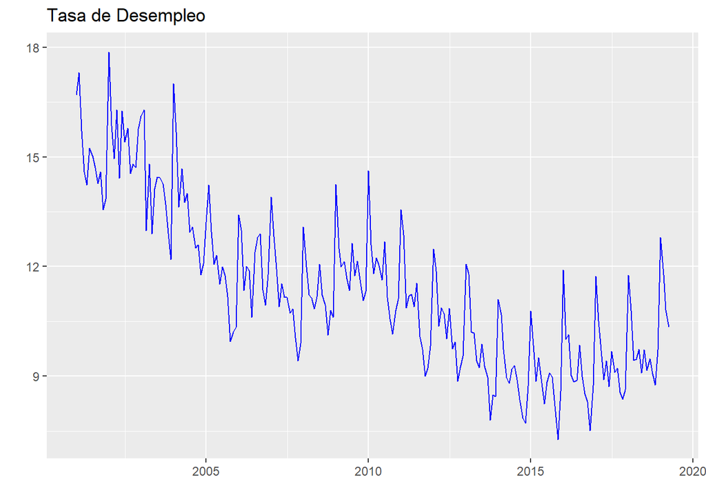

## 3. DETERMINAR SI LA SERIE ES HOMOCEDÁSTICA - PRUEBA DE BOX-COX

Para determinar si la varianza es constante, se realiza una prueba de Box-Cox, preferiblemente una que incluya un intervalo de confianza, en la cual, si el intervalo de confianza de lambda incluye a 1, no es necesario realizar ninguna transformación. Si el intervalo de confianza incluye el valor de Lambda igual a 0, se aplica la transformación por logaritmo. Para otros valores de lambda se utiliza la transformacion de Box-Cox. En este caso, el intervalo de confianza incluye al 0, por lo que se realiza una transformación de la serie original aplicándole logarítmo natural, para lograr que sea homocedástica.

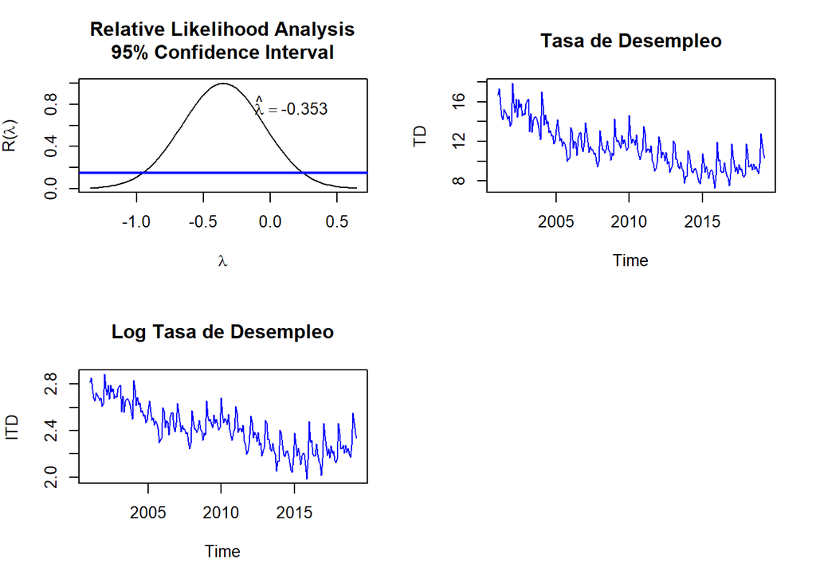

## 4. DETERMINAR SI LA SERIE ES ESTACIONARIA

### A. Prueba Dickey-Fuller

La Prueba de Dickey Fuller busca determinar la existencia o no de raíces unitarias en una serie de tiempo. Si la serie tiene raíces unitarias, implica que no es estacionaria, por lo que sería necesario aplicarle una diferenciación ordinaria para así lograr que sea estacionaria.

Para un nivel $\alpha*100\%$ de significancia previamente establecido, el test de Dickey Fuller busca contrastar la siguiente prueba de hipótesis:

$H_{0}:$ Hay presencia de una raíz unitaria - Serie No Estacionaria $H_{1}:$ No hay presencia de una raíz unitaria - Serie Estacionaria

La hipotesis nula de esta prueba es que existe una raiz unitaria en la serie, por lo que se busca rechazarla. Sin embargo, también es importante precisar que la prueba de Dickey-Fuller puede incorporar tres alternativas a evaluar:

- Serie con intercepto (**Drift**) y tendencia determinística.
- Serie con intercepto (**Drift**) pero sin tendencia determinística.
- Serie sin intercepto (sin **Drift**) y sin tendencia determinística.

Sí alguna de las pruebas concluye diferente con respecto a las demás es recomendable incluir más rezagos en el test ADF, puesto que la inclusión de más rezagos puede mejorar la precisión de la prueba.

Al utilizar los tres test con un solo rezago se encuentra que se rechaza la hipótesis nula considerando la presencia de intercepto y tendencia determinística, pero que no se rechaza cuando se supone que no hay intercepto ni tendencia, con un p-value = 0.3985, por lo que se considera necesario realizar una diferenciación ordinaria. Sin embargo, se volvería a realizar el test considerando hasta 10 rezagos para concluir si la serie presenta raíz unitaria y por tanto requiere ser diferenciada.

```
##
##  Augmented Dickey-Fuller Test
##
## data:  lTD
## Dickey-Fuller = -7.3343, Lag order = 1, p-value = 0.01
## alternative hypothesis: stationary
```

```
##
## Title:
##  Augmented Dickey-Fuller Test
##
## Test Results:
##   PARAMETER:
##     Lag Order: 1
##   STATISTIC:
##     Dickey-Fuller: -7.3343
##   P VALUE:
##     0.01
##
## Description:
##  Sun Jan 03 18:09:14 2021 by user: Carlos
```

```
##
## Title:
##  Augmented Dickey-Fuller Test
##
## Test Results:
##   PARAMETER:
##     Lag Order: 1
##   STATISTIC:
##     Dickey-Fuller: -4.0232
##   P VALUE:
##     0.01
##
## Description:
##  Sun Jan 03 18:09:14 2021 by user: Carlos
```

```
##
## Title:
##  Augmented Dickey-Fuller Test
##
## Test Results:
##   PARAMETER:
##     Lag Order: 1
##   STATISTIC:
##     Dickey-Fuller: -0.6814
##   P VALUE:
##     0.3985
##
## Description:
##  Sun Jan 03 18:09:14 2021 by user: Carlos
```

```
##
## ###############################################
## # Augmented Dickey-Fuller Test Unit Root Test #
## ###############################################
##
## Test regression none
##
##
## Call:
## lm(formula = z.diff ~ z.lag.1 - 1 + z.diff.lag)
##
## Residuals:
##      Min       1Q   Median       3Q      Max
## -0.21957 -0.06521 -0.01827  0.04152  0.35374
##
## Coefficients:
##             Estimate Std. Error t value Pr(>|t|)
## z.lag.1    -0.001929   0.002831  -0.681   0.4964
## z.diff.lag -0.138552   0.067325  -2.058   0.0408 *
## ---
## Signif. codes:  0 '***' 0.001 '**' 0.01 '*' 0.05 '.' 0.1 ' ' 1
##
## Residual standard error: 0.1013 on 216 degrees of freedom
## Multiple R-squared:  0.02129,    Adjusted R-squared:  0.01223
## F-statistic:  2.35 on 2 and 216 DF,  p-value: 0.09782
##
##
## Value of test-statistic is: -0.6814
##
## Critical values for test statistics:
##       1pct  5pct 10pct
## tau1 -2.58 -1.95 -1.62
```

### B. Incluyendo más Rezagos en la Prueba Dickey-Fuller

Al incluir hasta 10 rezagos en la prueba de Dickey Fuller Aumentada, mejora la precisión y se concluye que sí hay presencia de una raíz unitaria en la serie. Los resultados concluyen que en cada una de las pruebas existe la presencia de una raíz unitaria, puesto que los p-value son mayores que el $5\%$ de significancia. Por tanto se determina que es necesario diferenciar ordinariamente la serie.

```
##
##  Augmented Dickey-Fuller Test
##
## data:  lTD
## Dickey-Fuller = -0.85548, Lag order = 10, p-value = 0.9554
## alternative hypothesis: stationary
```

```
##
## Title:
##  Augmented Dickey-Fuller Test
##
## Test Results:
##   PARAMETER:
##     Lag Order: 10
##   STATISTIC:
##     Dickey-Fuller: -0.8555
##   P VALUE:
##     0.9554
##
## Description:
##  Sun Jan 03 18:09:14 2021 by user: Carlos
```

```
##
## Title:
##  Augmented Dickey-Fuller Test
##
## Test Results:
##   PARAMETER:
##     Lag Order: 10
##   STATISTIC:
##     Dickey-Fuller: -1.6404
##   P VALUE:
##     0.4463
##
## Description:
##  Sun Jan 03 18:09:14 2021 by user: Carlos
```

```
##
## Title:
##  Augmented Dickey-Fuller Test
##
## Test Results:
##   PARAMETER:
##     Lag Order: 10
##   STATISTIC:
##     Dickey-Fuller: -1.6545
##   P VALUE:
##     0.09449
##
## Description:
##  Sun Jan 03 18:09:14 2021 by user: Carlos
```

```
##
## ###############################################
## # Augmented Dickey-Fuller Test Unit Root Test #
## ###############################################
##
## Test regression none
##
##
## Call:
## lm(formula = z.diff ~ z.lag.1 - 1 + z.diff.lag)
##
## Residuals:
##       Min        1Q    Median        3Q       Max
## -0.195463 -0.055487 -0.007236  0.038742  0.253983
##
## Coefficients:
##               Estimate Std. Error t value Pr(>|t|)
## z.lag.1      -0.003898   0.002356  -1.654   0.0996 .
## z.diff.lag1  -0.408393   0.064304  -6.351 1.44e-09 ***
## z.diff.lag2  -0.480142   0.066980  -7.168 1.47e-11 ***
## z.diff.lag3  -0.475896   0.072454  -6.568 4.39e-10 ***
## z.diff.lag4  -0.372081   0.077818  -4.781 3.39e-06 ***
## z.diff.lag5  -0.504412   0.082045  -6.148 4.25e-09 ***
## z.diff.lag6  -0.168716   0.082317  -2.050   0.0417 *
## z.diff.lag7  -0.351787   0.078745  -4.467 1.33e-05 ***
## z.diff.lag8  -0.302199   0.074739  -4.043 7.54e-05 ***
## z.diff.lag9  -0.330116   0.068892  -4.792 3.24e-06 ***
## z.diff.lag10 -0.427938   0.065880  -6.496 6.54e-10 ***
## ---
## Signif. codes:  0 '***' 0.001 '**' 0.01 '*' 0.05 '.' 0.1 ' ' 1
##
## Residual standard error: 0.081 on 198 degrees of freedom
## Multiple R-squared:  0.4191, Adjusted R-squared:  0.3868
## F-statistic: 12.99 on 11 and 198 DF,  p-value: < 2.2e-16
##
##
## Value of test-statistic is: -1.6545
##
## Critical values for test statistics:
##       1pct  5pct 10pct
## tau1 -2.58 -1.95 -1.62
```

### C. Diferenciación Ordinaria de la Serie

Como no se rechazó la hipótesis Nula en el test de Dickey-Fuller sin tendencia ni intercepto, es necesario realizar una diferenciacion ordinaria. Una vez diferenciada, se vuelven a practicar los test de Dickey-Fuller. Los resultados a continuación permiten corroborar que no es necesario volver a diferenciar la serie, puesto que en todas las pruebas se rechaza $H_{0}$ al aplicar una diferencia ordinaria.

```
##
## Title:
##  Augmented Dickey-Fuller Test
##
## Test Results:
##   PARAMETER:
##     Lag Order: 10
##   STATISTIC:
##     Dickey-Fuller: -15.2321
##   P VALUE:
##     0.01
##
## Description:
##  Sun Jan 03 18:09:15 2021 by user: Carlos
```

```
##
## Title:
##  Augmented Dickey-Fuller Test
##
## Test Results:
##   PARAMETER:
##     Lag Order: 10
##   STATISTIC:
##     Dickey-Fuller: -14.8399
##   P VALUE:
##     0.01
##
## Description:
##  Sun Jan 03 18:09:15 2021 by user: Carlos
```

```
##
## Title:
##  Augmented Dickey-Fuller Test
##
## Test Results:
##   PARAMETER:
##     Lag Order: 10
##   STATISTIC:
##     Dickey-Fuller: -14.3123
##   P VALUE:
##     0.01
##
## Description:
##  Sun Jan 03 18:09:15 2021 by user: Carlos
```

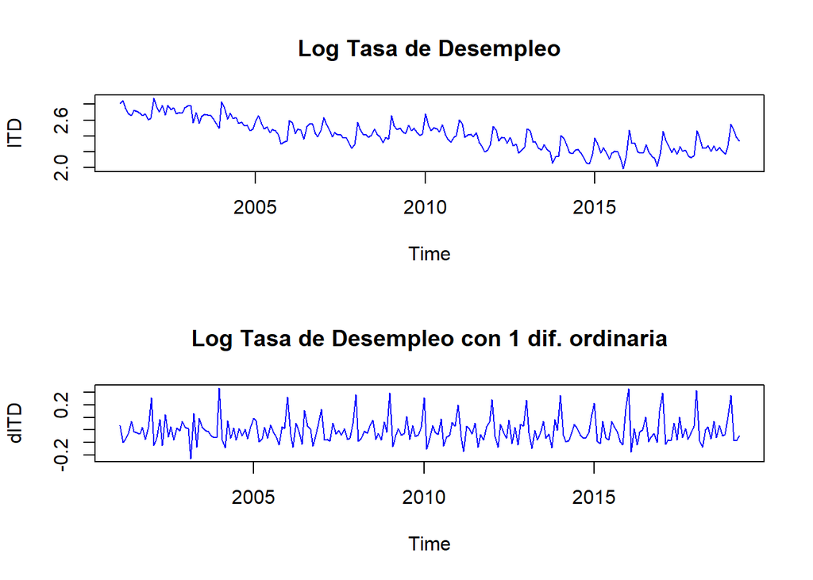

```
##
## ###############################################
## # Augmented Dickey-Fuller Test Unit Root Test #
## ###############################################
##
## Test regression none
##
##
## Call:
## lm(formula = z.diff ~ z.lag.1 - 1 + z.diff.lag)
##
## Residuals:
##      Min       1Q   Median       3Q      Max
## -0.21960 -0.06351 -0.02526  0.03077  0.32707
##
## Coefficients:
##            Estimate Std. Error t value Pr(>|t|)
## z.lag.1    -1.40440    0.10008 -14.033  < 2e-16 ***
## z.diff.lag  0.23441    0.06631   3.535 0.000499 ***
## ---
## Signif. codes:  0 '***' 0.001 '**' 0.01 '*' 0.05 '.' 0.1 ' ' 1
##
## Residual standard error: 0.0986 on 215 degrees of freedom
## Multiple R-squared:  0.593,  Adjusted R-squared:  0.5892
## F-statistic: 156.6 on 2 and 215 DF,  p-value: < 2.2e-16
##
##
## Value of test-statistic is: -14.0327
##
## Critical values for test statistics:
##       1pct  5pct 10pct
## tau1 -2.58 -1.95 -1.62
```

### D. Raíces Unitarias Estacionales

Para verificar si es necesario realizar una diferenciaciÓn estacional se revisa el comportamiento del monthplot. Si este indica que no hay estacionariedad estacional, entonces debe realizarse una diferenciación estacional. También se utiliza la prueba *nsdiffs* que indica cuántas diferencias estacionales es necesario realizar. Una vez diferenciada la serie se vuelven a calcular el monthplot y la prueba *nsdiffs*, lo que permite concluir que no es necesaria una diferenciación estacional adicional.

```
## [1] 1
```

```
## [1] 0
```

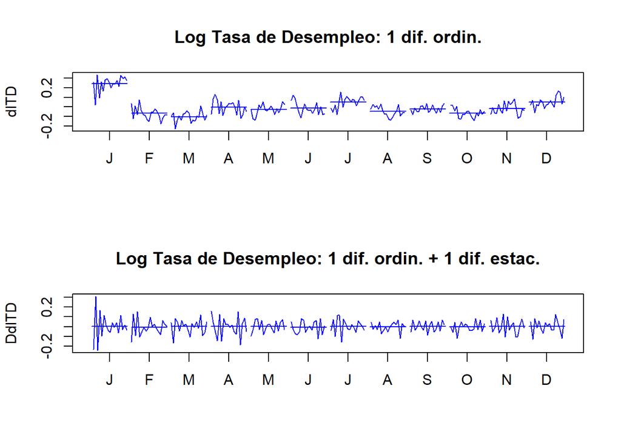

## 5. IDENTIFICACIÓN DE LOS ÓRDENES AUTORREGRESIVOS (AR) Y DE MEDIA MÓVIL (MA)

Una vez hechas todas las transformaciones para lograr que la serie sea estacioaria se construyen los plot de la Función de Autocorrelación Parcial PACF y de la Función de Auto Correlación Simple ACF. Mientras que el PACF nos da información sobre los $p$, es decir si hay presencia de estructuras autoregresivas (*AR*), el ACF nos da información sobre los $q$, es decir, si hay presencia estructuras de media móvil (*MA*). En este caso, los dos plot indican que el máximo **orden AR es 3**, mientras que el máximo **orden MA es 1**. Igualmente, las dos gráficas indican que posiblemente hay un **orden AR estacional = 1**, al igual que un **orden estacional MA = 1**. A continuación se construyen diferentes modelos y se evalúa la significancia de los coeficientes que resultan de cada uno de estos modelos.

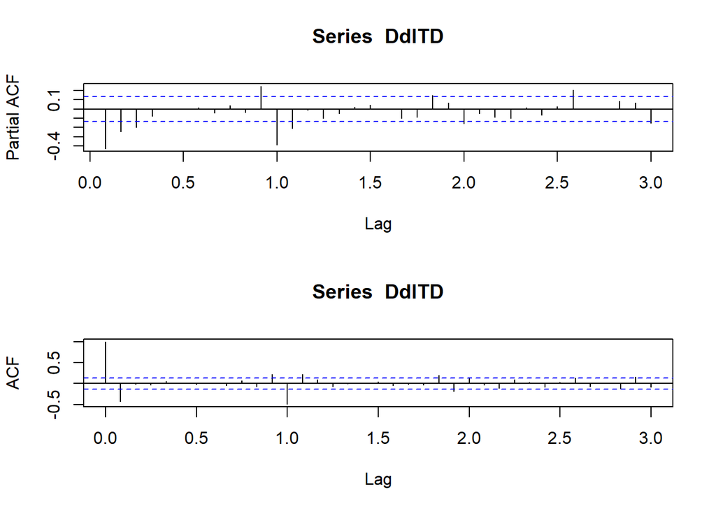

## 6. CONSTRUCCIÓN DE LOS MODELOS SARIMA

Para los siguientes modelos Arima que se construirán se tiene en cuenta las siguientes indicaciones:

- **Arima** $\mathbb{c(p,d,q)}$: $\mathbb{p=3}$ es el valor máximo del polinomio tipo *AR* identificado con *PACF*, $\mathbb{d=1}$ es el número de *diferenciaciones ordinarias* identificadas con *ADF*, $\mathbb{q=1}$ es el valor máximo del polinomio tipo *MA* identificado con *ACF*.
- $\mathbb{seasonal=list(P,D,Q)}$: $\mathbb{P=1}$ es el valor máximo del polinomio tipo *AR Estacional* identificado con *PACF*, $\mathbb{D=1}$ es el número de *diferenciaciones ordinarias* identificadas con *nsdiffs y monthplot*, $\mathbb{Q=1}$ es el valor máximo del polinomio tipo *MA Estacional* identificado con *ACF*.
- $\mathbb{lambda}$: indica el valor de la transformación de *Box-Cox* identificado con la prueba del mismo nombre.

Para los siguientes modelos propuestos se tienen en cuenta la cantidad de diferenciaciones ordinarias y estacionales que se han utilizado; para este caso, *1 diferencia ordinaria* y *1 diferencia estacional*. Posteriormente se construyen todos los modelos posibles y se revisa si los coeficientes son significativos; si no lo son es porque no existirían estructuras autorregresias y/o de media móvil que expliquen el valor esperado actual de la serie de tiempo.

```
## [1] "mod1 = Arima(TD, c(3, 1, 1),seasonal = list(order = c(1, 1, 1), period = 12),lambda = 0)"
```

```
##
## z test of coefficients:
##
##       Estimate Std. Error z value Pr(>|z|)
## ar1  -0.269910   0.233445 -1.1562   0.2476
## ar2  -0.136251   0.154976 -0.8792   0.3793
## ar3  -0.141790   0.096394 -1.4709   0.1413
## ma1  -0.366547   0.231471 -1.5836   0.1133
## sar1 -0.034281   0.103983 -0.3297   0.7416
## sma1 -0.725541   0.086362 -8.4012   <2e-16 ***
## ---
## Signif. codes:  0 '***' 0.001 '**' 0.01 '*' 0.05 '.' 0.1 ' ' 1
```

```
## [1] "mod2 = Arima(TD, c(2, 1, 1),seasonal = list(order = c(1, 1, 1), period = 12),lambda = 0)"
```

```
##
## z test of coefficients:
##
##       Estimate Std. Error z value  Pr(>|z|)
## ar1  -0.046779   0.149489 -0.3129    0.7543
## ar2   0.011363   0.108980  0.1043    0.9170
## ma1  -0.592750   0.131167 -4.5190 6.212e-06 ***
## sar1 -0.036598   0.106635 -0.3432    0.7314
## sma1 -0.716889   0.089984 -7.9669 1.627e-15 ***
## ---
## Signif. codes:  0 '***' 0.001 '**' 0.01 '*' 0.05 '.' 0.1 ' ' 1
```

```
## [1] "mod3 = Arima(TD, c(1, 1, 1),seasonal = list(order = c(1, 1, 1), period = 12),lambda = 0)"
```

```
##
## z test of coefficients:
##
##       Estimate Std. Error z value  Pr(>|z|)
## ar1  -0.057444   0.108598 -0.5290    0.5968
## ma1  -0.582212   0.086014 -6.7688 1.299e-11 ***
## sar1 -0.036974   0.106779 -0.3463    0.7291
## sma1 -0.715390   0.089026 -8.0358 9.298e-16 ***
## ---
## Signif. codes:  0 '***' 0.001 '**' 0.01 '*' 0.05 '.' 0.1 ' ' 1
```

```
## [1] "mod4 = Arima(TD, c(0, 1, 1),seasonal = list(order = c(1, 1, 1), period = 12),lambda = 0)"
```

```
##
## z test of coefficients:
##
##       Estimate Std. Error  z value  Pr(>|z|)
## ma1  -0.615913   0.052006 -11.8431 < 2.2e-16 ***
## sar1 -0.032659   0.106922  -0.3054      0.76
## sma1 -0.717494   0.089346  -8.0305 9.705e-16 ***
## ---
## Signif. codes:  0 '***' 0.001 '**' 0.01 '*' 0.05 '.' 0.1 ' ' 1
```

```
## [1] "mod5 = Arima(TD, c(3, 1, 0),seasonal = list(order = c(1, 1, 1), period = 12),lambda = 0)"
```

```
##
## z test of coefficients:
##
##       Estimate Std. Error z value  Pr(>|z|)
## ar1  -0.615830   0.068566 -8.9816 < 2.2e-16 ***
## ar2  -0.333969   0.078156 -4.2731 1.928e-05 ***
## ar3  -0.213289   0.068901 -3.0956  0.001964 **
## sar1 -0.023893   0.103388 -0.2311  0.817238
## sma1 -0.730204   0.085107 -8.5799 < 2.2e-16 ***
## ---
## Signif. codes:  0 '***' 0.001 '**' 0.01 '*' 0.05 '.' 0.1 ' ' 1
```

```
## [1] "mod6 = Arima(TD, c(2, 1, 0),seasonal = list(order = c(1, 1, 1), period = 12),lambda = 0)"
```

```
##
## z test of coefficients:
##
##       Estimate Std. Error z value  Pr(>|z|)
## ar1  -0.574317   0.068584 -8.3739 < 2.2e-16 ***
## ar2  -0.215823   0.069528 -3.1041  0.001909 **
## sar1 -0.030353   0.108141 -0.2807  0.778957
## sma1 -0.712959   0.092084 -7.7425  9.75e-15 ***
## ---
## Signif. codes:  0 '***' 0.001 '**' 0.01 '*' 0.05 '.' 0.1 ' ' 1
```

```
## [1] "mod7 = Arima(TD, c(1, 1, 0),seasonal = list(order = c(1, 1, 1), period = 12),lambda = 0)"
```

```
##
## z test of coefficients:
##
##       Estimate Std. Error z value  Pr(>|z|)
## ar1  -0.473351   0.061669 -7.6757 1.645e-14 ***
## sar1 -0.011238   0.098901 -0.1136    0.9095
## sma1 -0.761426   0.079045 -9.6328 < 2.2e-16 ***
## ---
## Signif. codes:  0 '***' 0.001 '**' 0.01 '*' 0.05 '.' 0.1 ' ' 1
```

```
## [1] "mod8 = Arima(TD, c(0, 1, 0),seasonal = list(order = c(1, 1, 1), period = 12),lambda = 0)"
```

```
##
## z test of coefficients:
##
##       Estimate Std. Error z value Pr(>|z|)
## sar1  0.046177   0.107436  0.4298   0.6673
## sma1 -0.764519   0.088652 -8.6239   <2e-16 ***
## ---
## Signif. codes:  0 '***' 0.001 '**' 0.01 '*' 0.05 '.' 0.1 ' ' 1
```

```
## [1] "mod1a = Arima(TD, c(3, 1, 1),seasonal = list(order = c(1, 1, 0), period = 12),lambda = 0)"
```

```
##
## z test of coefficients:
##
##       Estimate Std. Error z value Pr(>|z|)
## ar1  -0.262468   0.237580 -1.1048   0.2693
## ar2  -0.177947   0.150426 -1.1829   0.2368
## ar3  -0.122284   0.102238 -1.1961   0.2317
## ma1  -0.352929   0.234144 -1.5073   0.1317
## sar1 -0.534042   0.059683 -8.9480   <2e-16 ***
## ---
## Signif. codes:  0 '***' 0.001 '**' 0.01 '*' 0.05 '.' 0.1 ' ' 1
```

```
## [1] "mod2a = Arima(TD, c(2, 1, 1),seasonal = list(order = c(1, 1, 0), period = 12),lambda = 0)"
```

```
##
## z test of coefficients:
##
##       Estimate Std. Error z value  Pr(>|z|)
## ar1  -0.058601   0.149612 -0.3917    0.6953
## ar2  -0.051557   0.104599 -0.4929    0.6221
## ma1  -0.555832   0.134655 -4.1278 3.662e-05 ***
## sar1 -0.533123   0.059607 -8.9439 < 2.2e-16 ***
## ---
## Signif. codes:  0 '***' 0.001 '**' 0.01 '*' 0.05 '.' 0.1 ' ' 1
```

```
## [1] "mod3a = Arima(TD, c(1, 1, 1),seasonal = list(order = c(1, 1, 0), period = 12),lambda = 0)"
```

```
##
## z test of coefficients:
##
##        Estimate Std. Error z value  Pr(>|z|)
## ar1  -0.0092371  0.1088453 -0.0849    0.9324
## ma1  -0.6048239  0.0840288 -7.1978 6.118e-13 ***
## sar1 -0.5330465  0.0595286 -8.9545 < 2.2e-16 ***
## ---
## Signif. codes:  0 '***' 0.001 '**' 0.01 '*' 0.05 '.' 0.1 ' ' 1
```

```
## [1] "mod4a = Arima(TD, c(0, 1, 1),seasonal = list(order = c(1, 1, 0), period = 12),lambda = 0)"
```

```
##
## z test of coefficients:
##
##       Estimate Std. Error z value  Pr(>|z|)
## ma1  -0.610278   0.053283 -11.454 < 2.2e-16 ***
## sar1 -0.533093   0.059583  -8.947 < 2.2e-16 ***
## ---
## Signif. codes:  0 '***' 0.001 '**' 0.01 '*' 0.05 '.' 0.1 ' ' 1
```

```
## [1] "mod5a = Arima(TD, c(3, 1, 0),seasonal = list(order = c(1, 1, 0), period = 12),lambda = 0)"
```

```
##
## z test of coefficients:
##
##       Estimate Std. Error z value  Pr(>|z|)
## ar1  -0.596891   0.068300 -8.7392 < 2.2e-16 ***
## ar2  -0.359537   0.076224 -4.7169 2.395e-06 ***
## ar3  -0.200430   0.069487 -2.8844  0.003921 **
## sar1 -0.530450   0.059733 -8.8804 < 2.2e-16 ***
## ---
## Signif. codes:  0 '***' 0.001 '**' 0.01 '*' 0.05 '.' 0.1 ' ' 1
```

```
## [1] "mod6a = Arima(TD, c(2, 1, 0),seasonal = list(order = c(1, 1, 0), period = 12),lambda = 0)"
```

```
##
## z test of coefficients:
##
##       Estimate Std. Error z value  Pr(>|z|)
## ar1  -0.550944   0.067752 -8.1318 4.231e-16 ***
## ar2  -0.251155   0.067663 -3.7118 0.0002058 ***
## sar1 -0.527655   0.059549 -8.8609 < 2.2e-16 ***
## ---
## Signif. codes:  0 '***' 0.001 '**' 0.01 '*' 0.05 '.' 0.1 ' ' 1
```

```
## [1] "mod7a = Arima(TD, c(1, 1, 0),seasonal = list(order = c(1, 1, 0), period = 12),lambda = 0)"
```

```
##
## z test of coefficients:
##
##       Estimate Std. Error z value  Pr(>|z|)
## ar1  -0.438475   0.062551 -7.0099 2.385e-12 ***
## sar1 -0.527622   0.059531 -8.8630 < 2.2e-16 ***
## ---
## Signif. codes:  0 '***' 0.001 '**' 0.01 '*' 0.05 '.' 0.1 ' ' 1
```

```
## [1] "mod8a = Arima(TD, c(0, 1, 0),seasonal = list(order = c(1, 1, 0), period = 12),lambda = 0)"
```

```
##
## z test of coefficients:
##
##       Estimate Std. Error z value  Pr(>|z|)
## sar1 -0.527104   0.059947 -8.7929 < 2.2e-16 ***
## ---
## Signif. codes:  0 '***' 0.001 '**' 0.01 '*' 0.05 '.' 0.1 ' ' 1
```

```
## [1] "mod1b = Arima(TD, c(3, 1, 1),seasonal = list(order = c(0, 1, 0), period = 12),lambda = 0)"
```

```
##
## z test of coefficients:
##
##     Estimate Std. Error z value Pr(>|z|)
## ar1 -0.30883    0.27316 -1.1306   0.2582
## ar2 -0.20468    0.16742 -1.2225   0.2215
## ar3 -0.12868    0.10815 -1.1898   0.2341
## ma1 -0.29681    0.27192 -1.0916   0.2750
```

```
## [1] "mod2b = Arima(TD, c(2, 1, 1),seasonal = list(order = c(0, 1, 0), period = 12),lambda = 0)"
```

```
##
## z test of coefficients:
##
##      Estimate Std. Error z value  Pr(>|z|)
## ar1 -0.067835   0.159941 -0.4241 0.6714756
## ar2 -0.058442   0.108906 -0.5366 0.5915213
## ma1 -0.536932   0.146640 -3.6616 0.0002507 ***
## ---
## Signif. codes:  0 '***' 0.001 '**' 0.01 '*' 0.05 '.' 0.1 ' ' 1
```

```
## [1] "mod3b = Arima(TD, c(1, 1, 1),seasonal = list(order = c(0, 1, 0), period = 12),lambda = 0)"
```

```
##
## z test of coefficients:
##
##       Estimate Std. Error z value  Pr(>|z|)
## ar1 -0.0073669  0.1136509 -0.0648    0.9483
## ma1 -0.5972866  0.0895100 -6.6729 2.509e-11 ***
## ---
## Signif. codes:  0 '***' 0.001 '**' 0.01 '*' 0.05 '.' 0.1 ' ' 1
```

```
## [1] "mod4b = Arima(TD, c(0, 1, 1),seasonal = list(order = c(0, 1, 0), period = 12),lambda = 0)"
```

```
##
## z test of coefficients:
##
##      Estimate Std. Error z value  Pr(>|z|)
## ma1 -0.601861   0.054582 -11.027 < 2.2e-16 ***
## ---
## Signif. codes:  0 '***' 0.001 '**' 0.01 '*' 0.05 '.' 0.1 ' ' 1
```

```
## [1] "mod5b = Arima(TD, c(3, 1, 0),seasonal = list(order = c(0, 1, 0), period = 12),lambda = 0)"
```

```
##
## z test of coefficients:
##
##      Estimate Std. Error z value  Pr(>|z|)
## ar1 -0.592215   0.068439 -8.6531 < 2.2e-16 ***
## ar2 -0.358616   0.076262 -4.7024 2.571e-06 ***
## ar3 -0.197599   0.069301 -2.8513  0.004354 **
## ---
## Signif. codes:  0 '***' 0.001 '**' 0.01 '*' 0.05 '.' 0.1 ' ' 1
```

```
## [1] "mod6b = Arima(TD, c(2, 1, 0),seasonal = list(order = c(0, 1, 0), period = 12),lambda = 0)"
```

```
##
## z test of coefficients:
##
##      Estimate Std. Error z value  Pr(>|z|)
## ar1 -0.546966   0.067873 -8.0587  7.71e-16 ***
## ar2 -0.251873   0.067757 -3.7173 0.0002014 ***
## ---
## Signif. codes:  0 '***' 0.001 '**' 0.01 '*' 0.05 '.' 0.1 ' ' 1
```

```
## [1] "mod7b = Arima(TD, c(1, 1, 0),seasonal = list(order = c(0, 1, 0), period = 12),lambda = 0)"
```

```
##
## z test of coefficients:
##
##      Estimate Std. Error z value  Pr(>|z|)
## ar1 -0.437538   0.063119 -6.9319 4.151e-12 ***
## ---
## Signif. codes:  0 '***' 0.001 '**' 0.01 '*' 0.05 '.' 0.1 ' ' 1
```

```
## [1] "mod1c = Arima(TD, c(3, 1, 1),seasonal = list(order = c(0, 1, 1), period = 12),lambda = 0)"
```

```
##
## z test of coefficients:
##
##       Estimate Std. Error  z value Pr(>|z|)
## ar1  -0.270654   0.236825  -1.1428   0.2531
## ar2  -0.137083   0.156379  -0.8766   0.3807
## ar3  -0.142848   0.096683  -1.4775   0.1395
## ma1  -0.363072   0.234916  -1.5455   0.1222
## sma1 -0.745392   0.057416 -12.9824   <2e-16 ***
## ---
## Signif. codes:  0 '***' 0.001 '**' 0.01 '*' 0.05 '.' 0.1 ' ' 1
```

```
## [1] "mod2c = Arima(TD, c(2, 1, 1),seasonal = list(order = c(0, 1, 1), period = 12),lambda = 0)"
```

```
##
## z test of coefficients:
##
##       Estimate Std. Error  z value  Pr(>|z|)
## ar1  -0.042211   0.150384  -0.2807    0.7789
## ar2   0.013267   0.109466   0.1212    0.9035
## ma1  -0.594665   0.132535  -4.4869 7.228e-06 ***
## sma1 -0.739023   0.057837 -12.7776 < 2.2e-16 ***
## ---
## Signif. codes:  0 '***' 0.001 '**' 0.01 '*' 0.05 '.' 0.1 ' ' 1
```

```
## [1] "mod3c = Arima(TD, c(1, 1, 1),seasonal = list(order = c(0, 1, 1), period = 12),lambda = 0)"
```

```
##
## z test of coefficients:
##
##       Estimate Std. Error  z value  Pr(>|z|)
## ar1  -0.054889   0.108996  -0.5036    0.6146
## ma1  -0.582290   0.086666  -6.7188 1.833e-11 ***
## sma1 -0.737644   0.056779 -12.9914 < 2.2e-16 ***
## ---
## Signif. codes:  0 '***' 0.001 '**' 0.01 '*' 0.05 '.' 0.1 ' ' 1
```

```
## [1] "mod4c = Arima(TD, c(0, 1, 1),seasonal = list(order = c(0, 1, 1), period = 12),lambda = 0)"
```

```
##
## z test of coefficients:
##
##       Estimate Std. Error z value  Pr(>|z|)
## ma1  -0.614930   0.052112 -11.800 < 2.2e-16 ***
## sma1 -0.737257   0.057115 -12.908 < 2.2e-16 ***
## ---
## Signif. codes:  0 '***' 0.001 '**' 0.01 '*' 0.05 '.' 0.1 ' ' 1
```

```
## [1] "mod5c = Arima(TD, c(3, 1, 0),seasonal = list(order = c(0, 1, 1), period = 12),lambda = 0)"
```

```
##
## z test of coefficients:
##
##       Estimate Std. Error  z value  Pr(>|z|)
## ar1  -0.614206   0.068238  -9.0010 < 2.2e-16 ***
## ar2  -0.333005   0.078002  -4.2692 1.962e-05 ***
## ar3  -0.213523   0.068881  -3.0999  0.001936 **
## sma1 -0.744028   0.057373 -12.9682 < 2.2e-16 ***
## ---
## Signif. codes:  0 '***' 0.001 '**' 0.01 '*' 0.05 '.' 0.1 ' ' 1
```

```
## [1] "mod6c = Arima(TD, c(2, 1, 0),seasonal = list(order = c(0, 1, 1), period = 12),lambda = 0)"
```

```
##
## z test of coefficients:
##
##       Estimate Std. Error  z value  Pr(>|z|)
## ar1  -0.572587   0.068352  -8.3770 < 2.2e-16 ***
## ar2  -0.214607   0.069368  -3.0938  0.001976 **
## sma1 -0.731736   0.058662 -12.4737 < 2.2e-16 ***
## ---
## Signif. codes:  0 '***' 0.001 '**' 0.01 '*' 0.05 '.' 0.1 ' ' 1
```

```
## [1] "mod7c = Arima(TD, c(1, 1, 0),seasonal = list(order = c(0, 1, 1), period = 12),lambda = 0)"
```

```
##
## z test of coefficients:
##
##       Estimate Std. Error  z value  Pr(>|z|)
## ar1  -0.472963   0.061574  -7.6813 1.575e-14 ***
## sma1 -0.767514   0.056727 -13.5299 < 2.2e-16 ***
## ---
## Signif. codes:  0 '***' 0.001 '**' 0.01 '*' 0.05 '.' 0.1 ' ' 1
```

```
## [1] "mod8c = Arima(TD, c(0, 1, 0),seasonal = list(order = c(0, 1, 1), period = 12),lambda = 0)"
```

```
##
## z test of coefficients:
##
##       Estimate Std. Error z value  Pr(>|z|)
## sma1 -0.734637   0.062273 -11.797 < 2.2e-16 ***
## ---
## Signif. codes:  0 '***' 0.001 '**' 0.01 '*' 0.05 '.' 0.1 ' ' 1
```

## 7. ANÁLISIS DE RESIDUALES DE LOS MODELOS SELECCIONADOS

De los modelos construidos se seleccionaron los modelos 4a, 5a, 6a, 7a, 8a, 4b, 5b, 6b, 7b, 4c, 5c, 6c, 7c y 8c, puesto que fueron aquellos en los que todos los coeficientes resultaron significativos en el test de coeficientes. Posteriormente, se procede a realizar los test de normalidad (Jarque-Bera) y de independencia o ausencia de autocorrelación en los residuos de cada modelo (Ljung-Box), para los cuales se espera no rechazar la $H_{0}$ de cada uno de los test. Específicamente, las pruebas de hipótesis a evaluar en cada uno de los modelos seleccionados son:

- **Test de Normalidad de los Residuos (Jarque-Bera):**
  - $H_{0}:$ Los residuos siguen una distribución Normal
  - $H_{1}:$ Los residuos No siguen una distribución Normal
- **Test de Independencia o de Ausencia de Autocorrelación de los Residuos (Ljung-Box):**
  - $H_{0}:$ Los residuos son independientes entre sí - Los residuos No están Autocorrelacionados
  - $H_{1}:$ Los residuos No son independientes entre sí - Los residuos están Autocorrelacionados

```
## [1] "Modelo 4a, Arima((0, 1, 1),seasonal (1, 1, 0))"
```

```
##
##  Jarque Bera Test
##
## data:  mod4a$residuals
## X-squared = 0.53499, df = 2, p-value = 0.7653
```

```
##
##  Box-Ljung test
##
## data:  mod4a$residuals
## X-squared = 86.575, df = 55, p-value = 0.004213
```

```
## [1] "Modelo 5a, Arima((3, 1, 0),seasonal (1, 1, 0))"
```

```
##
##  Jarque Bera Test
##
## data:  mod5a$residuals
## X-squared = 0.6752, df = 2, p-value = 0.7135
```

```
##
##  Box-Ljung test
##
## data:  mod5a$residuals
## X-squared = 85.557, df = 55, p-value = 0.005202
```

```
## [1] "Modelo 6a, Arima((2, 1, 0),seasonal (1, 1, 0))"
```

```
##
##  Jarque Bera Test
##
## data:  mod6a$residuals
## X-squared = 0.4178, df = 2, p-value = 0.8115
```

```
##
##  Box-Ljung test
##
## data:  mod6a$residuals
## X-squared = 105.1, df = 55, p-value = 5.539e-05
```

```
## [1] "Modelo 7a, Arima((1, 1, 0),seasonal (1, 1, 0))"
```

```
##
##  Jarque Bera Test
##
## data:  mod7a$residuals
## X-squared = 0.35072, df = 2, p-value = 0.8392
```

```
##
##  Box-Ljung test
##
## data:  mod7a$residuals
## X-squared = 138.25, df = 55, p-value = 4.119e-09
```

```
## [1] "Modelo 8a, Arima((0, 1, 0),seasonal (1, 1, 0))"
```

```
##
##  Jarque Bera Test
##
## data:  mod8a$residuals
## X-squared = 2.9671, df = 2, p-value = 0.2268
```

```
##
##  Box-Ljung test
##
## data:  mod8a$residuals
## X-squared = 143.5, df = 55, p-value = 7.84e-10
```

```
## [1] "Modelo 4b, Arima((0, 1, 1),seasonal (0, 1, 0))"
```

```
##
##  Jarque Bera Test
##
## data:  mod4b$residuals
## X-squared = 7.6549, df = 2, p-value = 0.02177
```

```
##
##  Box-Ljung test
##
## data:  mod4b$residuals
## X-squared = 114.67, df = 55, p-value = 4.342e-06
```

```
## [1] "Modelo 5b, Arima((3, 1, 0),seasonal (0, 1, 0))"
```

```
##
##  Jarque Bera Test
##
## data:  mod5b$residuals
## X-squared = 6.1876, df = 2, p-value = 0.04533
```

```
##
##  Box-Ljung test
##
## data:  mod5b$residuals
## X-squared = 116.77, df = 55, p-value = 2.424e-06
```

```
## [1] "Modelo 6b, Arima((2, 1, 0),seasonal (0, 1, 0))"
```

```
##
##  Jarque Bera Test
##
## data:  mod6b$residuals
## X-squared = 10.229, df = 2, p-value = 0.006008
```

```
##
##  Box-Ljung test
##
## data:  mod6b$residuals
## X-squared = 130.35, df = 55, p-value = 4.656e-08
```

```
## [1] "Modelo 7b, Arima((1, 1, 0),seasonal (0, 1, 0))"
```

```
##
##  Jarque Bera Test
##
## data:  mod7b$residuals
## X-squared = 15.05, df = 2, p-value = 0.0005395
```

```
##
##  Box-Ljung test
##
## data:  mod7b$residuals
## X-squared = 158.23, df = 55, p-value = 6.291e-12
```

```
## [1] "Modelo 4c, Arima((0, 1, 1),seasonal (0, 1, 1))"
```

```
##
##  Jarque Bera Test
##
## data:  mod4c$residuals
## X-squared = 4.005, df = 2, p-value = 0.135
```

```
##
##  Box-Ljung test
##
## data:  mod4c$residuals
## X-squared = 57.849, df = 55, p-value = 0.3705
```

```
## [1] "Modelo 5c, Arima((3, 1, 0),seasonal (0, 1, 1))"
```

```
##
##  Jarque Bera Test
##
## data:  mod5c$residuals
## X-squared = 3.5594, df = 2, p-value = 0.1687
```

```
##
##  Box-Ljung test
##
## data:  mod5c$residuals
## X-squared = 60.007, df = 55, p-value = 0.2992
```

```
## [1] "Modelo 6c, Arima((2, 1, 0),seasonal (0, 1, 1))"
```

```
##
##  Jarque Bera Test
##
## data:  mod6c$residuals
## X-squared = 3.4385, df = 2, p-value = 0.1792
```

```
##
##  Box-Ljung test
##
## data:  mod6c$residuals
## X-squared = 72.236, df = 55, p-value = 0.05942
```

```
## [1] "Modelo 7c, Arima((1, 1, 0),seasonal (0, 1, 1))"
```

```
##
##  Jarque Bera Test
##
## data:  mod7c$residuals
## X-squared = 2.339, df = 2, p-value = 0.3105
```

```
##
##  Box-Ljung test
##
## data:  mod7c$residuals
## X-squared = 89.285, df = 55, p-value = 0.002368
```

```
## [1] "Modelo 8c, Arima((0, 1, 0),seasonal (0, 1, 1))"
```

```
##
##  Jarque Bera Test
##
## data:  mod8c$residuals
## X-squared = 3.7221, df = 2, p-value = 0.1555
```

```
##
##  Box-Ljung test
##
## data:  mod8c$residuals
## X-squared = 141.32, df = 55, p-value = 1.565e-09
```

Una vez realizados los test se encuentra que los modelos que cumplen con los supuestos de normalidad y de no autocorrelación de los residuos son:

- Modelo 4c, Arima((0, 1, 1),seasonal (0, 1, 1))
- Modelo 5c, Arima((3, 1, 0),seasonal (0, 1, 1))
- Modelo 6c, Arima((2, 1, 0),seasonal (0, 1, 1))

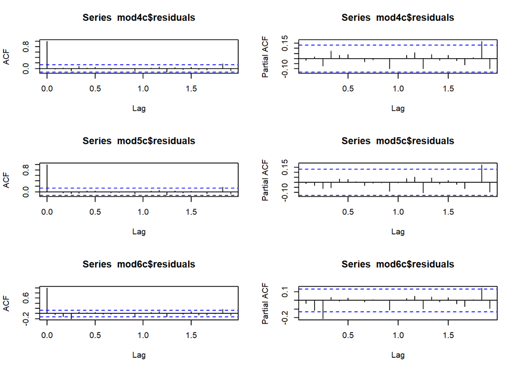

## 8. INCLUSIÓN DE VARIABLES DUMMIES DE OUTLIERS COMO VARIABLES REGRESORAS

Una vez seleccionados los modelos finales, se procede a realizar la inclusión de variables Dummies como variables regresoras adicionales a cada modelo. La inclusión de estas variables permite mejorar la precisión del modelo, toda vez que permite controlar el efecto de una alteración sorpresiva en algún rezago de los residuales el cual no logra ser explicado por el modelo SARIMA propuesto. Los outliers se clasifican en 3 tipos:

- **AO - Outlier Aditivo:** el cual solo ocurre en un rezago determinado
- **LS - Salto de Nivel:** el cual ocurre cuando en un rezago determinado los residuales sufren una alteración y no logran retornar al mismo nivel como estaba en un inicio.
- **TC - Cambio Transitorio:** el cual ocurre cuando en un rezago determinado los residuales sufren una alteración; pero después de contados periodos siguientes logran retornar al mismo nivel como estaba en un inicio.

### A. Análisis de Outliers - Modelo 4C

Se realiza el análisis de outliers para el modelo 4c, en el cual se hallan los siguientes 4 outliers en los residuales del modelo:

| observación | tipo |
| --- | --- |
| 24 | AO (Outlier aditivo) |
| 25 | LS (Salto de nivel) |
| 67 | LS (Salto de nivel) - No resulta significativo. Se retira |
| 68 | TC (Cambio Transitorio) |

Al realizar un test de coeficientes se encuentra que el 67 (LS) no resulta significativo al 95% de confianza, por lo que se elimina y se construye una matriz con los efectos de tres outliers restantes y se incluyen en el modelo *mod4cConOultliers*:

```
##   type ind    coefhat     tstat
## 1   AO  24  0.1318638  3.593024
## 2   LS  25 -0.1397649 -4.337389
## 3   LS  67  0.1142049  3.544031
## 5   TC  68  0.1397929  3.884938
```

```
##
## z test of coefficients:
##
##       Estimate Std. Error  z value  Pr(>|z|)
## ma1  -0.655778   0.044530 -14.7266 < 2.2e-16 ***
## sma1 -0.711454   0.065010 -10.9438 < 2.2e-16 ***
## AO24  0.094285   0.045969   2.0510 0.0402624 *
## LS25 -0.110862   0.038270  -2.8968 0.0037696 **
## TC68  0.147815   0.038417   3.8477 0.0001193 ***
## ---
## Signif. codes:  0 '***' 0.001 '**' 0.01 '*' 0.05 '.' 0.1 ' ' 1
```

#### A.1. Nuevo Análisis de Outliers e Inclusión en el Modelo 4C

Posteriormente, se evalúa nuevamente si hay outliers en el nuevo modelo *mod4cConOultliers*, lo que se muestra en la salida de abajo que hay un nuevo outlier en la observación #49, de tipo AO (Outlier Aditivo). Por tal razón, se construye un vector con los efectos de este nuevo outlier y se adiciona a la matriz con los efectos de los otros tres outliers ya identificados, para luego incorporar los cuatro outliers en el modelo *mod4cConOultliers2*. Al revisar la existencia de outliers adicionales en este último modelo no se encuentra ninguno adicional, por lo que se considera que el modelo ya está completamente especificado.

```
##   type ind    coefhat    tstat
## 1   AO  49 -0.1352362 -3.80752
```

```
##
## z test of coefficients:
##
##       Estimate Std. Error  z value  Pr(>|z|)
## ma1  -0.639865   0.046195 -13.8514 < 2.2e-16 ***
## sma1 -0.706077   0.069058 -10.2244 < 2.2e-16 ***
## AO24  0.093542   0.044669   2.0941 0.0362500 *
## LS25 -0.119750   0.038120  -3.1414 0.0016815 **
## TC68  0.147282   0.037523   3.9251  8.67e-05 ***
## AO49 -0.137300   0.038772  -3.5412 0.0003983 ***
## ---
## Signif. codes:  0 '***' 0.001 '**' 0.01 '*' 0.05 '.' 0.1 ' ' 1
```

```
## [1] type    ind     coefhat tstat
## <0 rows> (or 0-length row.names)
```

#### A.2. Análisis de Estabilidad de los Parámetros - CUSUM Y CUSUM^2 - Modelo *mod4cConOutliers2*

Después de tener el modelo completamente especificado, se considera necesario analizar si los parámetros del mismo son estables. Para este propósito se utilizan los **test CUSUM (estabilidad de los parámetros)** y **CUSUMQ (homogeneidad del proceso)**. En el caso del modelo previamente especificado no se encuentra ningún indicio en las dos gráficas que permita suponer que el proceso no es homogeneo o que los parámetros no son estables, pues no se salen de los límites de confianza calculados.

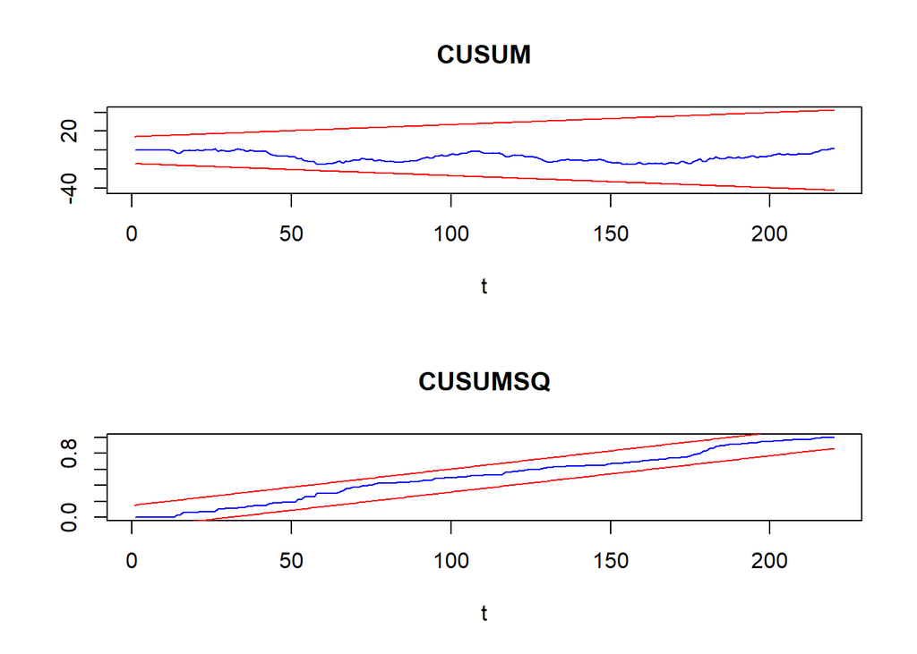

### B. Análisis de Outliers - Modelo 5C

Se realiza el análisis de outliers para el modelo 5c, en el cual se hallan los siguientes 3 outliers en los residuales del modelo:

| observación | tipo |
| --- | --- |
| 66 | AO (Outlier aditivo) |
| 25 | LS (Salto de nivel) |
| 68 | TC (Cambio Transitorio) |

Por lo tanto, se construye una matriz incluyendo los efectos de estos tres outliers y se incluyen en el modelo *mod5cConOultliers*, al que se le realiza un test de coeficientes, encontrando que todos los outliers incorporados resultan significativos al 95% de confianza.

```
##   type ind    coefhat     tstat
## 1   AO  66 -0.1307885 -3.567505
## 2   LS  25 -0.1395761 -4.155097
## 3   TC  68  0.1297780  3.615738
```

```
##
## z test of coefficients:
##
##       Estimate Std. Error  z value  Pr(>|z|)
## ar1  -0.670962   0.069489  -9.6556 < 2.2e-16 ***
## ar2  -0.368037   0.079871  -4.6079 4.068e-06 ***
## ar3  -0.197002   0.069906  -2.8181  0.004831 **
## sma1 -0.733277   0.060082 -12.2046 < 2.2e-16 ***
## AO66 -0.101032   0.040680  -2.4836  0.013007 *
## LS25 -0.151881   0.036044  -4.2138 2.511e-05 ***
## TC68  0.114891   0.038640   2.9734  0.002945 **
## ---
## Signif. codes:  0 '***' 0.001 '**' 0.01 '*' 0.05 '.' 0.1 ' ' 1
```

#### B.1. Nuevo Análisis de Outliers e Inclusión en el Modelo 5C

Posteriormente, se evalúa nuevamente si hay outliers en el nuevo modelo *mod5cConOultliers*, lo que arroja que hay un nuevo outlier en la observación #49, de tipo AO (Outlier Aditivo). Por tal razón, se construye un vector con los efectos de este nuevo outlier y se adiciona a la matriz con los efectos de los otros tres outliers ya identificados, para luego incorporar los cuatro outliers en el modelo *mod5cConOultliers2*. Al revisar la existencia de outliers adicionales en este último modelo no se encuentra ninguno, por lo que se considera que el modelo ya está completamente especificado.

```
##   type ind    coefhat     tstat
## 1   AO  49 -0.1389446 -4.067297
```

```
##
## z test of coefficients:
##
##       Estimate Std. Error  z value  Pr(>|z|)
## ar1  -0.656429   0.070202  -9.3506 < 2.2e-16 ***
## ar2  -0.335026   0.080744  -4.1492 3.336e-05 ***
## ar3  -0.186527   0.070656  -2.6399 0.0082922 **
## sma1 -0.737132   0.062949 -11.7099 < 2.2e-16 ***
## AO66 -0.101145   0.039331  -2.5716 0.0101226 *
## LS25 -0.161118   0.035616  -4.5238 6.074e-06 ***
## TC68  0.115840   0.037851   3.0605 0.0022100 **
## AO49 -0.142062   0.038000  -3.7385 0.0001851 ***
## ---
## Signif. codes:  0 '***' 0.001 '**' 0.01 '*' 0.05 '.' 0.1 ' ' 1
```

```
## [1] type    ind     coefhat tstat
## <0 rows> (or 0-length row.names)
```

#### B.2. Análisis de Estabilidad de los Parámetros - CUSUM Y CUSUM^2 - Modelo *mod5cConOutliers2*

Después de tener el modelo completamente especificado, se considera necesario analizar si los parámetros del mismo son estables. Para este propósito se utilizan los test CUSUM (estabilidad de los par?metros) y CUSUMQ (homogeneidad del proceso). En el caso del modelo previamente especificado no se encuentra ningún indicio en las dos gr?ficas que permita suponer que el proceso no es homogeneo o que los parámetros no son estables, pues no se salen de los límites calculados.

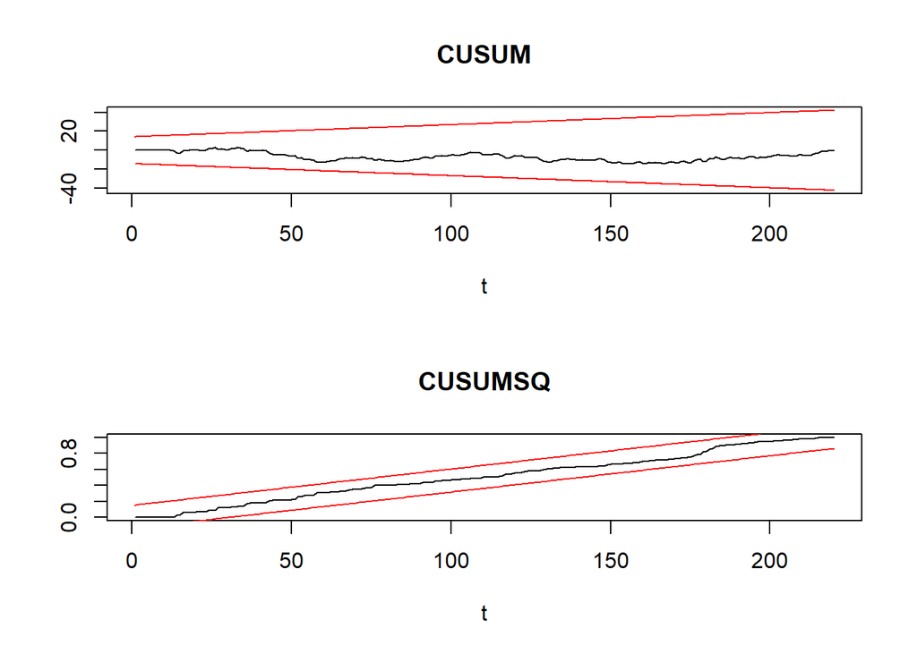

### C. Análisis de Outliers - Modelo 6C

Se realiza el análisis de outliers para el modelo 6c, en el cual se hallan los siguientes 6 outliers en los residuales del modelo:

| observación | tipo |
| --- | --- |
| 36 | AO (Outlier aditivo) |
| 24 | AO (Outlier aditivo) - No resulta significativo. No se tiene en cuenta |
| 49 | AO (Outlier aditivo) |
| 66 | AO (Outlier aditivo) |
| 25 | LS (Salto de nivel) |
| 68 | TC (Cambio Transitorio) |

Por lo tanto, se construye una matriz incluyendo los efectos de estos seis outliers y se incluyen en el modelo *mod6cConOultliers*, al que se le realiza un test de coeficientes, encontrando que todos los outliers incorporados -a excepcion del AO24- resultan significativos al 95% de confianza, de esta manera se construye un modelo correctamente especificado con los cinco outliers significativos.

```
##   type ind    coefhat     tstat
## 1   AO  24  0.1358055  3.839386
## 2   AO  36 -0.1254173 -3.545691
## 3   AO  49 -0.1270661 -3.592286
## 4   AO  66 -0.1393917 -3.940639
## 5   LS  25 -0.1513777 -4.306396
## 7   TC  68  0.1392847  3.885343
```

```
##
## z test of coefficients:
##
##       Estimate Std. Error  z value  Pr(>|z|)
## ar1  -0.618861   0.070126  -8.8250 < 2.2e-16 ***
## ar2  -0.216302   0.070035  -3.0885 0.0020119 **
## sma1 -0.718926   0.066106 -10.8753 < 2.2e-16 ***
## AO36 -0.102331   0.037132  -2.7559 0.0058537 **
## AO49 -0.142551   0.036768  -3.8770 0.0001058 ***
## AO66 -0.101434   0.039055  -2.5972 0.0093985 **
## LS25 -0.166247   0.037220  -4.4667 7.945e-06 ***
## TC68  0.115370   0.038951   2.9619 0.0030572 **
## ---
## Signif. codes:  0 '***' 0.001 '**' 0.01 '*' 0.05 '.' 0.1 ' ' 1
```

#### C.1. Nuevo Análisis de Outliers e Inclusión en el Modelo 6C

Posteriormente, se evalúa nuevamente si hay outliers en el nuevo modelo *mod6cConOultliers*. Sin embargo, al revisar la existencia de outliers adicionales en este último modelo no se encuentra ninguno, por lo que se considera que el modelo ya está completamente especificado.

```
## [1] type    ind     coefhat tstat
## <0 rows> (or 0-length row.names)
```

#### C.2. Análisis de Estabilidad de los Parámetros - CUSUM Y CUSUM^2 - Modelo *mod6cConOultliers*

Después de tener el modelo completamente especificado, se considera necesario analizar si los parámetros del mismo son estables. Para este propósito se utilizan los test CUSUM (estabilidad de los parámetros) y CUSUMQ (homogeneidad del proceso). En el caso del modelo previamente especificado no se encuentra ningún indicio en las dos gráficas que permita suponer que el proceso no es homogeneo o que los parámetros no son estables, pues no se salen de los límites calculados.

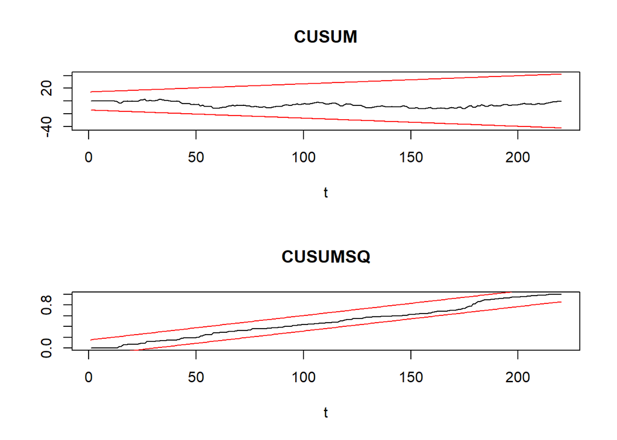

## 9. EVALUACIÓN DE PRONÓSTICOS A TRAVÉS DE ROLLING - AJUSTE DE PRONÓSTICOS CON MUESTRA ENTRENAMIENTO Y PRUEBA A LOS MODELOS SARIMA(X)

Con el fin de validar diferentes modelos para pronosticar 1 y 2 pasos adelante, se computa el método de *Rolling* con el fin de crear pronósticos secuenciales, para esto se fija una muestra de entrenamiento (80%) y otra de prueba (20%), tal que con la muestra de entrenamiento se pronostique *h* pasos adelante y el resultado se compara con el dato real (u observado) en la muestra de prueba. Para realizar el ejercicio de manera secuencial, al modelo se le incluirá cada vez una observación más del grupo de prueba y se volverá a pronosticar *h* pasos adelante con el fin de comparar el valor pronosticado con el real. Finalmente, se computará el *Error Cuadrático Medio (ECM)* de los pronósticos con los datos reales y así calcular una medida estadística que permita verificar la calidad del modelo en cuanto a su capacidad de pronóstico, la cual se compará con otros modelos propuestos, cabe mencionar que entre menor sea el *ECM* mejor es el modelo para pronositicar *h* pasos adelante.

### A. Pronósticos a Través de Rolling - Modelo *mod4c*

#### A.1. Pronósticos a 1 Paso Adelante - *mod4c*

```
## [1] 0.1951314
```

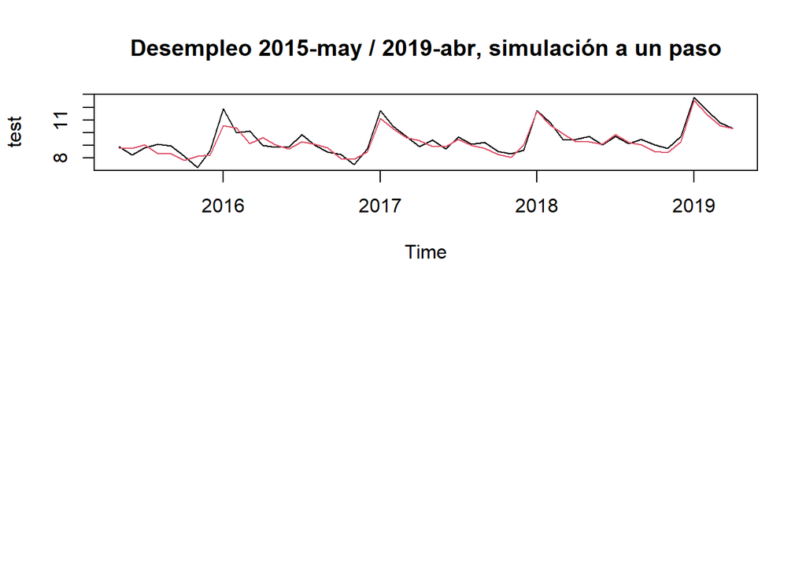

#### A.2. Pronósticos a 2 Pasos Adelante - *mod4c*

```
## [1] 0.2163152
```

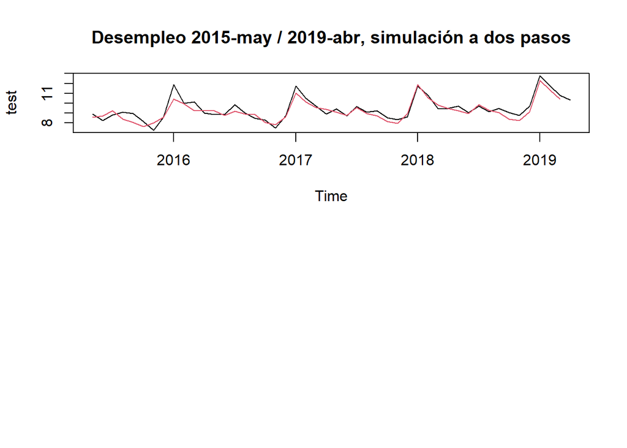

### B. Pronósticos a Través de Rolling - Modelo *mod5c*

#### B.1. Pronósticos a 1 Paso Adelante - *mod5c*

```
## [1] 0.2001813
```

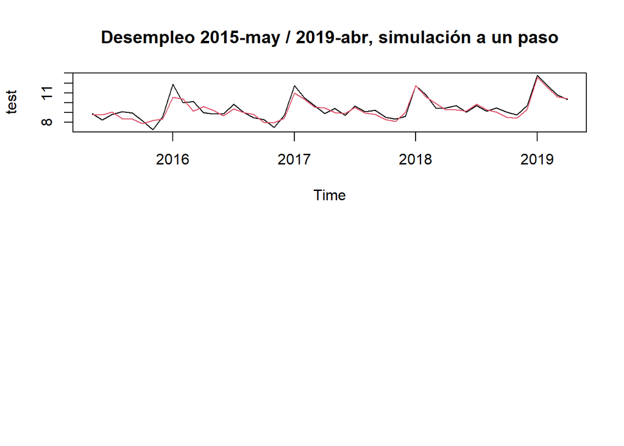

#### B.2. Pronósticos a 2 Pasos Adelante - *mod5c*

```
## [1] 0.2173829
```

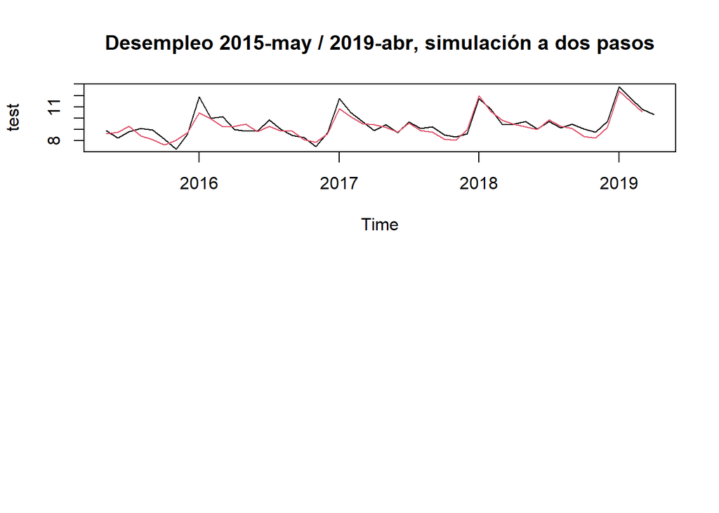

### C. Pronósticos a Través de Rolling - Modelo *mod6c*

#### C.1. Pronósticos a 1 Paso Adelante - *mod6c*

```
## [1] 0.2158058
```

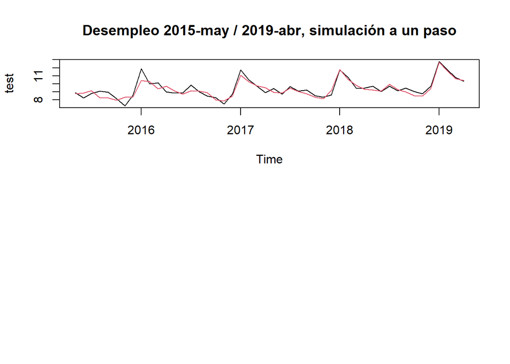

#### C.2. Pronósticos a 2 Pasos Adelante - *mod6c*

```
## [1] 0.244608
```

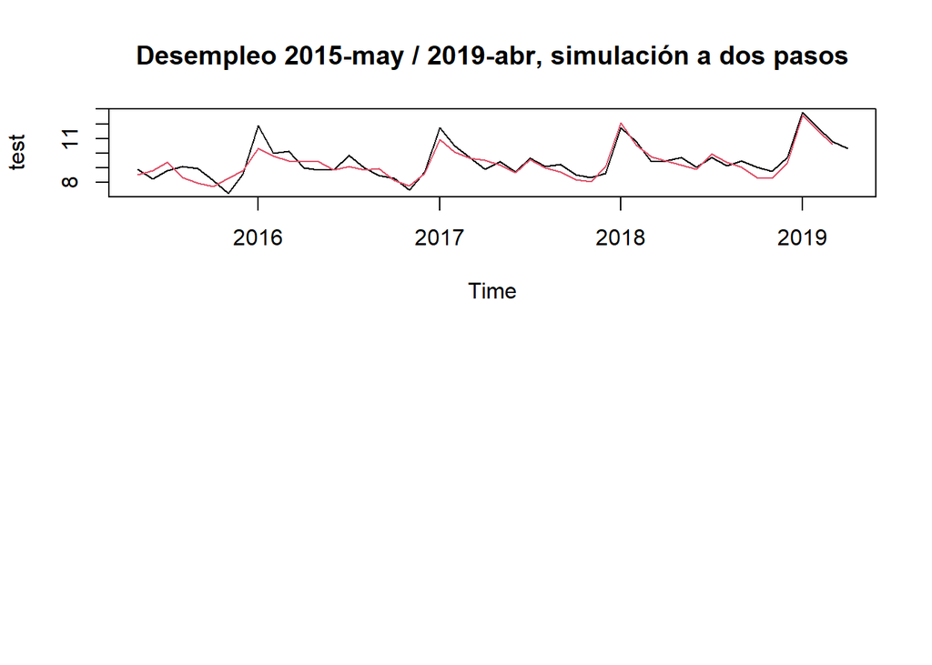

## 10. ESTIMACIÓN DE MODELOS DE SERIES DE TIEMPO DE FORMA ESTRUCTURAL

La estimación de modelos de forma estructural parte de descomponer las series de tiempo y analizar cada uno de sus componentes por separado: tendencia, ciclo, estacionalidad y componente irregular. Para estimar los pronósticos se proyecta cada componente *h* pasos adelante y al final se suman para obtener los pronósticos de la serie original. Los modelos de forma estructural más conocidos son los de tipo *STL* y de *Suavisamiento Exponencial Holt-Winters*

### A. Descomposición y Pronóstico Usando Método STL

Se muestra la descomposición y pronóstico usando el método STL

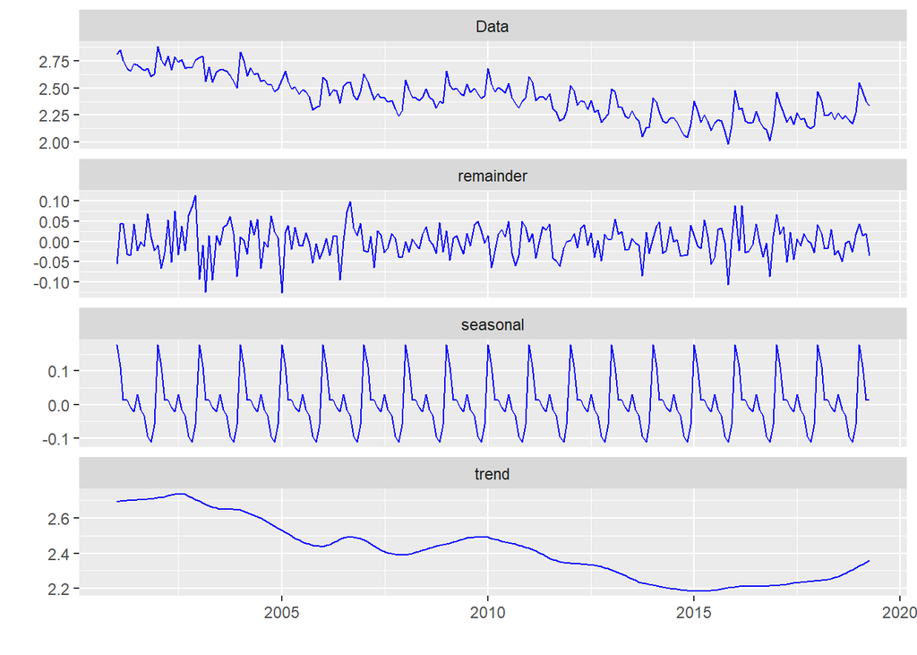

#### A.1. Pronósticos a 1 Paso Adelante - *modelo STL*

```
## [1] 1.377919
```

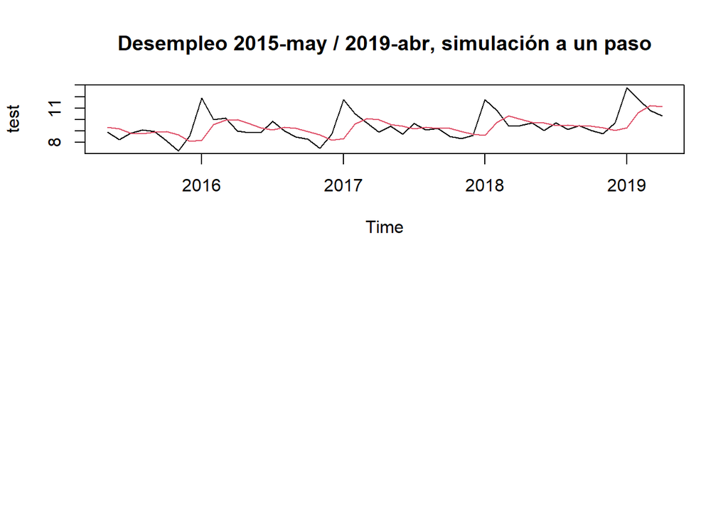

#### A.2. Pronósticos a 2 Pasos Adelante - *modelo STL*

```
## [1] 1.322958
```

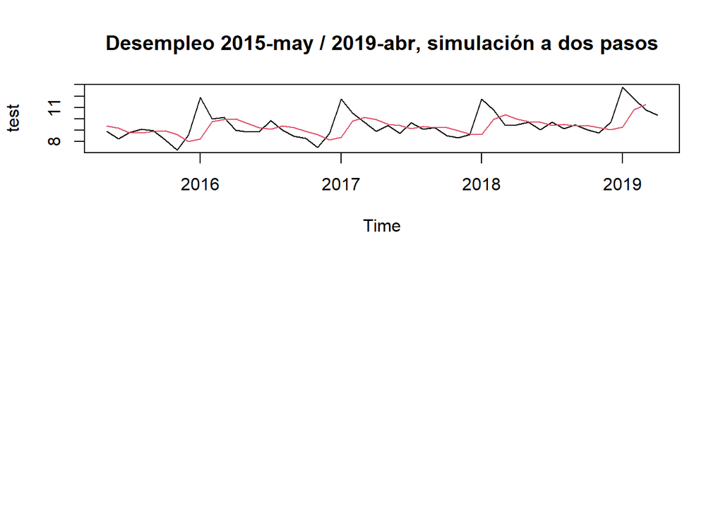

### B. Descomposión y Pronóstico Usando Método de Suavisamiento Exponencial - Holt-Winters (Método Paramétrico)

Se muestra la descomposición y pronóstico usando el método de suaviazamiento exponencial (método paramétrico) llamado Holt Winters

```
##     alpha
## 0.3385768
```

```
##       beta
## 0.02979223
```

```
##     gamma
## 0.4161721
```

```
##            a            b           s1           s2           s3           s4
##  2.341927282  0.002228882 -0.002125894 -0.052583898  0.027424890 -0.030632737
##           s5           s6           s7           s8           s9          s10
## -0.035303776 -0.105277755 -0.145996580 -0.053082845  0.226356523  0.127209429
##          s11          s12
##  0.031529445 -0.006643953
```

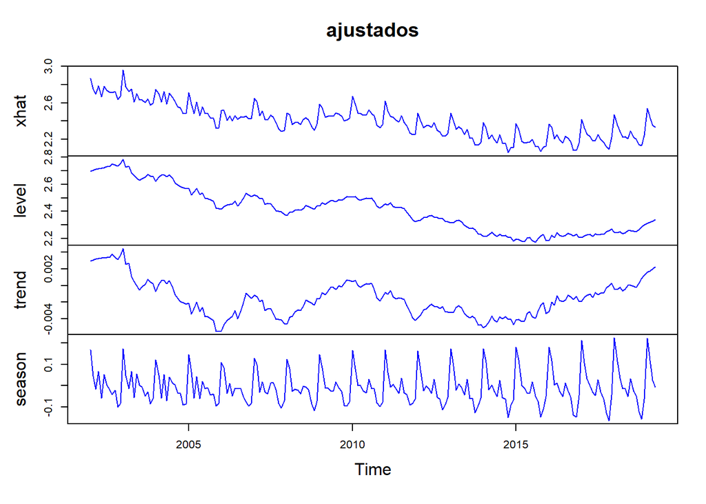

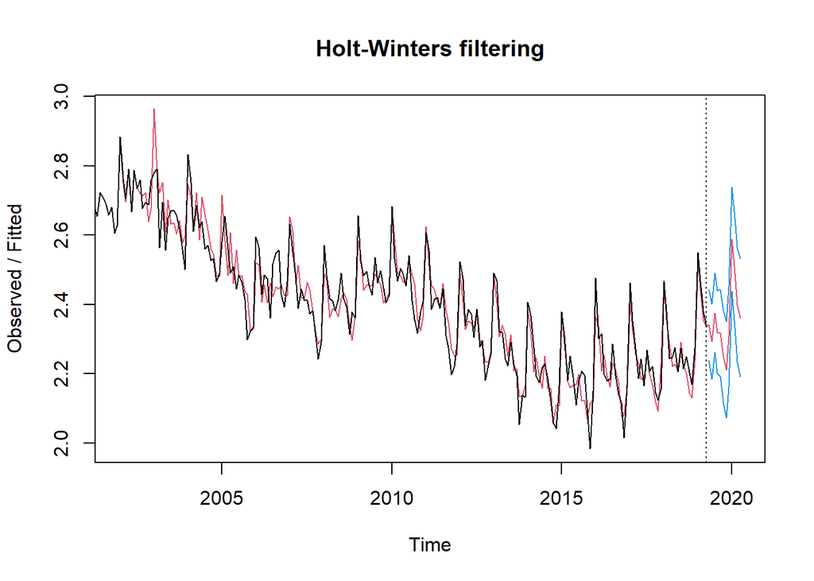

#### B.1. Pronósticos a 1 Paso Adelante - *modelo Holt-Winters*

```
## [1] 0.1962645
```

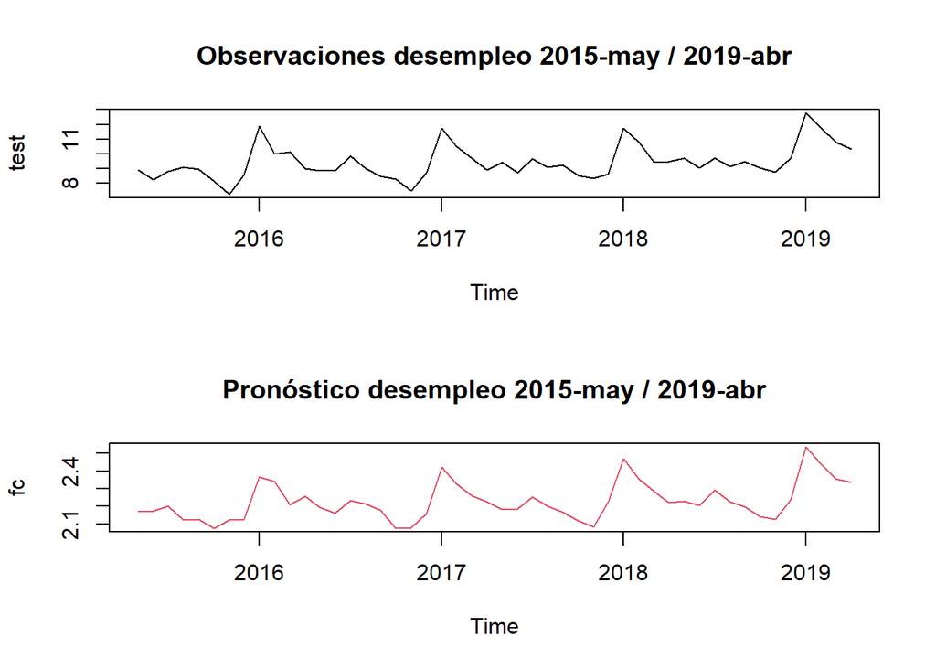

#### B.2. Pronósticos a 2 Pasos Adelante - *modelo Holt-Winters*

```
## [1] 1.305812
```

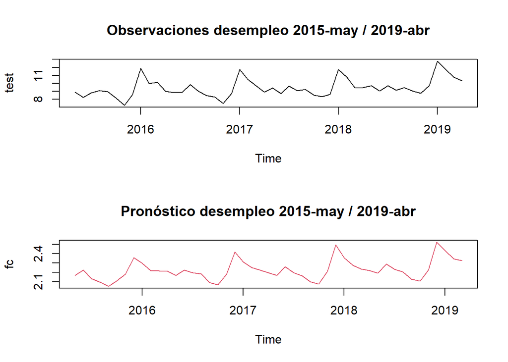

## 11. SELECCIÓN DEL MOEJOR MODELO PARA PRONÓSTICO

A continuación, se selecciona el **modelo 4c, Arima(0, 1, 1),seasonal (0, 1, 1)**, puesto que arrojó el menor *Error Cuadrático Medio (ECM)* tanto a un paso como a dos pasos adelante.

```
## [1] "Modelo 4c, Arima(0, 1, 1),seasonal (0, 1, 1), rolling a un paso"
```

```
## [1] 0.1951314
```

```
## [1] "Modelo 4c, Arima(0, 1, 1),seasonal (0, 1, 1), rolling a dos pasos"
```

```
## [1] 0.2163152
```

```
## [1] "Modelo 5c, Arima((3, 1, 0),seasonal (0, 1, 1)), rolling a un paso"
```

```
## [1] 0.2001813
```

```
## [1] "Modelo 5c, Arima((3, 1, 0),seasonal (0, 1, 1)), rolling a dos pasos"
```

```
## [1] 0.2173829
```

```
## [1] "Modelo 6c, Arima((2, 1, 0),seasonal (0, 1, 1)), rolling a un paso"
```

```
## [1] 0.2158058
```

```
## [1] "Modelo 6c, Arima((2, 1, 0),seasonal (0, 1, 1)), rolling a dos pasos"
```

```
## [1] 0.244608
```

```
## [1] "Modelo estructural STL, rolling a un paso"
```

```
## [1] 1.377919
```

```
## [1] "Modelo estructural STL, rolling a dos pasos"
```

```
## [1] 1.322958
```

```
## [1] "Modelo estructural HW, rolling a un paso"
```

```
## [1] 0.1962645
```

```
## [1] "Modelo estructural HW, rolling a dos pasos"
```

```
## [1] 1.305812
```

## 12. PRONÓSTICOS CON EL MODELO SELECCIONADO

Después de evaluar la estabilidad de los parámetros y la homogeneidad del proceso, y una vez seleccionado el modelo 4c por el menor ECM, es posible realizar pronósticos con el mismo. A continuación se estima el comportamiento de la serie de desempleo en Colombia para los próximos 12 meses posteriores a la última observación disponible (abril de 2019), es decir, para el periodo comprendido entre mayo de 2019 y abril de 2020, con un intervalo de confianza del 95%. Dado que el modelo tiene outliers, es necesario antes proyectar la matriz de outliers en la misma cantidad de pasos que se desea simular, lo que se hace en la matriz *xregforecast*, que se incorpora a la función *forecast* y a la función *predict*.

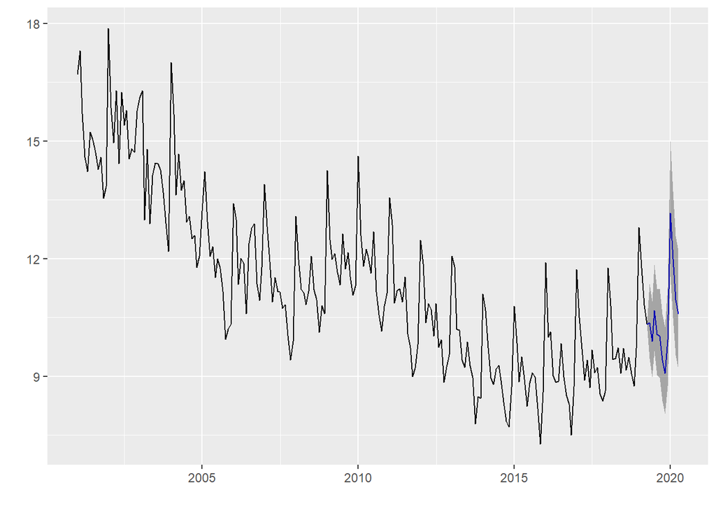

```
##          Point Forecast     Lo 95    Hi 95
## May 2019      10.366708  9.461602 11.35840
## Jun 2019       9.898975  8.982961 10.90840
## Jul 2019      10.689058  9.647476 11.84309
## Aug 2019      10.073726  9.045401 11.21895
## Sep 2019      10.036939  8.968187 11.23306
## Oct 2019       9.417446  8.375129 10.58948
## Nov 2019       9.086188  8.044037 10.26336
## Dec 2019       9.935832  8.757921 11.27217
## Jan 2020      13.162434 11.553162 14.99586
## Feb 2020      11.998020 10.488166 13.72523
## Mar 2020      10.957239  9.540449 12.58443
## Apr 2020      10.585232  9.181078 12.20414
```